## Improving Science Synthesis for Forest Managers

#### Forest Sustainability Capstone Project and Beyond

[figure not shown]

The proposal combines conceptual models, overview text, coding of information, links to details and links to publications. It is also expandable, and able to be modified as new research is published. The goal is to create an easily-accessible platform that managers can use to become informed on the literature surrounding the area they are managing.

Here is an example of what the home page could look like -

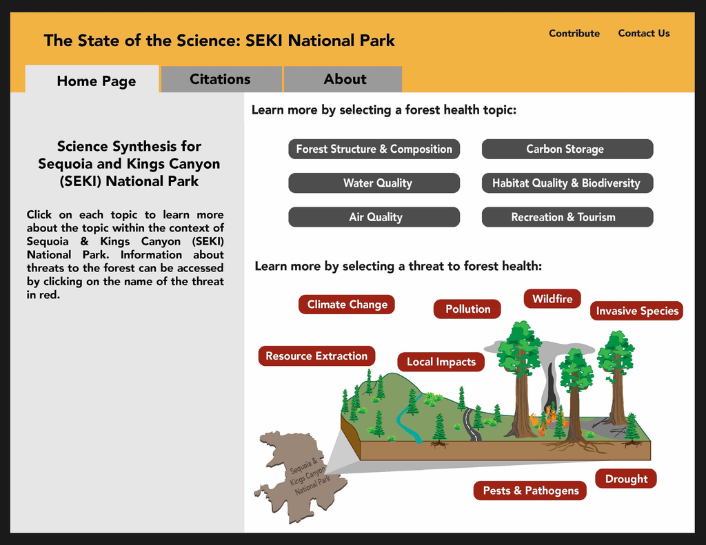

We used Sequoia and Kings Canyon National Parks as a case study for our science synthesis system because its large size and wide variety of ecosystem types make it representative of other areas across the US, and it is subject to common threats such as wildfire and climate change. In addition, the parks’ iconic sequoia trees and high visitation rate create unique management objectives and threats beyond those found in other forests, resulting in an ideal focus area for our science synthesis system. Finally, California’s forests have been well studied, so a significant amount of scientific information already exists, which is critical for our science synthesis system to be useful and effective.